# Credit Card Default

Dareck Giuliani, Jacob Summerhays, and Sam Wilson

12/2/2020

# Define

Primarily, we intend to create a model that predicts default rate. We will also answer the following questions:

1. How does the probability of default payment vary by categories of different demographic variables?
2. Which variables are the strongest predictors of default payment?

# Collect

## The Raw Data

This dataset contains information about default payments, demographic factors, credit data, history of payment, and bill statements of credit card clients in Taiwan from April 2005 to September 2005.

### Variables

#### Independent Variables

- ID: ID of each client
- LIMIT_BAL: Amount of given credit in NT dollars (includes individual and family/supplementary credit
- SEX: Gender (1=male, 2=female)
- EDUCATION: (1=graduate school, 2=university, 3=high school, 4=others, 5=unknown, 6=unknown)
- MARRIAGE: Marital status (1=married, 2=single, 3=others)
- AGE: Age in years
- PAY_0: Repayment status in September, 2005 (-1=pay duly, 1=payment delay for one month, 2=payment delay for two months, … 8=payment delay for eight months, 9=payment delay for nine months and above)
- PAY_2: Repayment status in August, 2005 (scale same as above)
- PAY_3: Repayment status in July, 2005 (scale same as above)
- PAY_4: Repayment status in June, 2005 (scale same as above)
- PAY_5: Repayment status in May, 2005 (scale same as above)
- PAY_6: Repayment status in April, 2005 (scale same as above)
- BILL_AMT1: Amount of bill statement in September, 2005 (NT dollar)
- BILL_AMT2: Amount of bill statement in August, 2005 (NT dollar)
- BILL_AMT3: Amount of bill statement in July, 2005 (NT dollar)
- BILL_AMT4: Amount of bill statement in June, 2005 (NT dollar)
- BILL_AMT5: Amount of bill statement in May, 2005 (NT dollar)
- BILL_AMT6: Amount of bill statement in April, 2005 (NT dollar)
- PAY_AMT1: Amount of previous payment in September, 2005 (NT dollar)
- PAY_AMT2: Amount of previous payment in August, 2005 (NT dollar)
- PAY_AMT3: Amount of previous payment in July, 2005 (NT dollar)
- PAY_AMT4: Amount of previous payment in June, 2005 (NT dollar)
- PAY_AMT5: Amount of previous payment in May, 2005 (NT dollar)
- PAY_AMT6: Amount of previous payment in April, 2005 (NT dollar)

#### Dependent Variables

- default.payment.next.month: Default payment (1=yes, 0=no)

```r
#read in data
creditDf <- read.csv('UCI_Credit_Card.csv')
#https://www.kaggle.com/uciml/default-of-credit-card-clients-dataset

#standardize column names
colnames(creditDf) <- tolower(make.names(colnames(creditDf)))

head(creditDf)
```

```
##   id limit_bal sex education marriage age pay_0 pay_2 pay_3 pay_4 pay_5 pay_6
## 1  1     20000   2         2        1  24     2     2    -1    -1    -2    -2
## 2  2    120000   2         2        2  26    -1     2     0     0     0     2
## 3  3     90000   2         2        2  34     0     0     0     0     0     0
## 4  4     50000   2         2        1  37     0     0     0     0     0     0
## 5  5     50000   1         2        1  57    -1     0    -1     0     0     0
## 6  6     50000   1         1        2  37     0     0     0     0     0     0
##   bill_amt1 bill_amt2 bill_amt3 bill_amt4 bill_amt5 bill_amt6 pay_amt1 pay_amt2
## 1      3913      3102       689         0         0         0        0      689
## 2      2682      1725      2682      3272      3455      3261        0     1000
## 3     29239     14027     13559     14331     14948     15549     1518     1500
## 4     46990     48233     49291     28314     28959     29547     2000     2019
## 5      8617      5670     35835     20940     19146     19131     2000    36681
## 6     64400     57069     57608     19394     19619     20024     2500     1815
##   pay_amt3 pay_amt4 pay_amt5 pay_amt6 default.payment.next.month
## 1        0        0        0        0                          1
## 2     1000     1000        0     2000                          1
## 3     1000     1000     1000     5000                          0
## 4     1200     1100     1069     1000                          0
## 5    10000     9000      689      679                          0
## 6      657     1000     1000      800                          0
```

# Organize

## Cleaning the Data

```r
#dimensions
dim(creditDf)
```

```
## [1] 30000    25
```

```r
#missing values
sum(is.na(creditDf))
```

```
## [1] 0
```

```r
#summary
summary(creditDf)
```

```
##        id          limit_bal            sex          education
##  Min.   :    1   Min.   :  10000   Min.   :1.000   Min.   :0.000
##  1st Qu.: 7501   1st Qu.:  50000   1st Qu.:1.000   1st Qu.:1.000
##  Median :15000   Median : 140000   Median :2.000   Median :2.000
##  Mean   :15000   Mean   : 167484   Mean   :1.604   Mean   :1.853
##  3rd Qu.:22500   3rd Qu.: 240000   3rd Qu.:2.000   3rd Qu.:2.000
##  Max.   :30000   Max.   :1000000   Max.   :2.000   Max.   :6.000
##     marriage          age            pay_0             pay_2
##  Min.   :0.000   Min.   :21.00   Min.   :-2.0000   Min.   :-2.0000
##  1st Qu.:1.000   1st Qu.:28.00   1st Qu.:-1.0000   1st Qu.:-1.0000
##  Median :2.000   Median :34.00   Median : 0.0000   Median : 0.0000
##  Mean   :1.552   Mean   :35.49   Mean   :-0.0167   Mean   :-0.1338
##  3rd Qu.:2.000   3rd Qu.:41.00   3rd Qu.: 0.0000   3rd Qu.: 0.0000
##  Max.   :3.000   Max.   :79.00   Max.   : 8.0000   Max.   : 8.0000
##      pay_3             pay_4             pay_5             pay_6
##  Min.   :-2.0000   Min.   :-2.0000   Min.   :-2.0000   Min.   :-2.0000
##  1st Qu.:-1.0000   1st Qu.:-1.0000   1st Qu.:-1.0000   1st Qu.:-1.0000
##  Median : 0.0000   Median : 0.0000   Median : 0.0000   Median : 0.0000
##  Mean   :-0.1662   Mean   :-0.2207   Mean   :-0.2662   Mean   :-0.2911
##  3rd Qu.: 0.0000   3rd Qu.: 0.0000   3rd Qu.: 0.0000   3rd Qu.: 0.0000
##  Max.   : 8.0000   Max.   : 8.0000   Max.   : 8.0000   Max.   : 8.0000
##    bill_amt1         bill_amt2        bill_amt3         bill_amt4
##  Min.   :-165580   Min.   :-69777   Min.   :-157264   Min.   :-170000
##  1st Qu.:   3559   1st Qu.:  2985   1st Qu.:   2666   1st Qu.:   2327
##  Median :  22382   Median : 21200   Median :  20089   Median :  19052
##  Mean   :  51223   Mean   : 49179   Mean   :  47013   Mean   :  43263
##  3rd Qu.:  67091   3rd Qu.: 64006   3rd Qu.:  60165   3rd Qu.:  54506
##  Max.   : 964511   Max.   :983931   Max.   :1664089   Max.   : 891586
##    bill_amt5        bill_amt6          pay_amt1         pay_amt2
##  Min.   :-81334   Min.   :-339603   Min.   :     0   Min.   :      0
##  1st Qu.:  1763   1st Qu.:   1256   1st Qu.:  1000   1st Qu.:    833
##  Median : 18105   Median :  17071   Median :  2100   Median :   2009
##  Mean   : 40311   Mean   :  38872   Mean   :  5664   Mean   :   5921
##  3rd Qu.: 50191   3rd Qu.:  49198   3rd Qu.:  5006   3rd Qu.:   5000
##  Max.   :927171   Max.   : 961664   Max.   :873552   Max.   :1684259
##     pay_amt3         pay_amt4         pay_amt5           pay_amt6
##  Min.   :     0   Min.   :     0   Min.   :     0.0   Min.   :     0.0
##  1st Qu.:   390   1st Qu.:   296   1st Qu.:   252.5   1st Qu.:   117.8
##  Median :  1800   Median :  1500   Median :  1500.0   Median :  1500.0
##  Mean   :  5226   Mean   :  4826   Mean   :  4799.4   Mean   :  5215.5
##  3rd Qu.:  4505   3rd Qu.:  4013   3rd Qu.:  4031.5   3rd Qu.:  4000.0
##  Max.   :896040   Max.   :621000   Max.   :426529.0   Max.   :528666.0
##  default.payment.next.month
##  Min.   :0.0000
##  1st Qu.:0.0000
##  Median :0.0000
##  Mean   :0.2212
##  3rd Qu.:0.0000
##  Max.   :1.0000
```

```r
# What is the ratio of defaults?
sum(creditDf$default.payment.next.month)/length(creditDf$default.payment.next.month)
```

```
## [1] 0.2212
```

### Correcting the Data Types

1. Alter Sex to be a 0-1 variable and ensure it is categorical.
2. Education has one level for other and two levels for unknown. Each of these will be grouped together.
3. Education had a few entries of 0, this will be grouped with other and unknown.
4. Education is then made into a categorical variable.
5. Marriage is made into a categorical variable.
6. Marriage has a few entries of 0. These value has no meaning, it will be grouped with other.
7. The dependent variable, credit default, it made into a categorical variable.
8. Each of the pay variables is made into a categorical variable.
9. Each of the pay variables has an entry of -2. This is an erroneous entry and instead the absolute value is used.

### Feature Engineering

```r
creditDf <- creditDf %>%
  mutate(

    # Data Cleaning

    # Make sex a binary variable (1=female, 0 = male) and make it categorical.
    sex = as.factor(if_else(creditDf$sex == 2, true = 1, false = 0)),

    # Education contains these three repetitive levels: 4=others, 5=unknown, 6=unknown. This next line is to consolidate the the three levels into one level. Additionally, some entries have education labeled as 0. 0 is not a known level according to the given key. As such, 0 will be grouped with others and unknown. Education is made into a categorical variable as well.
    education = as.factor(ifelse(creditDf$education > 4 | creditDf$education == 0, 4, creditDf$education)),

    # Some entries of marriage are labeled as 0. However, the key given to us, does not provide meaning for 0. Thus, values for marriage of 0 will be grouped into the other bin.
    #make marriage a categorical variable
    marriage = as.factor(ifelse(creditDf$marriage == 0, 3, creditDf$marriage)),

    # The dependent variable is made into a categorical variable (1 = yes, 0 = no).
    default.payment.next.month = as.factor(creditDf$default.payment.next.month),

    # The pay variables have values of -2. However, -2 is never provided in the key. I am imputing the absolute value instead. Each pay variable is made into a categorical variable.
    pay_0 = factor(ifelse(creditDf$pay_0 == -2, 2, creditDf$pay_0)),
    pay_2 = factor(ifelse(creditDf$pay_2 == -2, 2, creditDf$pay_2)),
    pay_3 = factor(ifelse(creditDf$pay_3 == -2, 2, creditDf$pay_3)),
    pay_4 = factor(ifelse(creditDf$pay_4 == -2, 2, creditDf$pay_4)),
    pay_5 = factor(ifelse(creditDf$pay_5 == -2, 2, creditDf$pay_5)),
    pay_6 = factor(ifelse(creditDf$pay_6 == -2, 2, creditDf$pay_6)),



    # Feature Engineering

    bill_avg = round((creditDf$bill_amt1 + creditDf$bill_amt2 + creditDf$bill_amt3 + creditDf$bill_amt4 + creditDf$bill_amt5 + creditDf$bill_amt6)/6, 2),

    pay_avg = round((creditDf$pay_amt1 + creditDf$pay_amt2 +creditDf$pay_amt3 + creditDf$pay_amt4 + creditDf$pay_amt5 + creditDf$pay_amt6 ) /6,2),

    #Credit scores often judge a person on their credit usage. The closer to the limit a person is, the more of a negative impact on credit score. This metric will divide the average bill amount by the limit balance to get a sense of the average credit usage.
    avg_credit_usage = round(bill_avg/limit_bal, 2),


  ) %>%

  # ID is dropped as it will have no predictive power.
  select(-c(id))

# This will show the data type of each variable within the data frame.
sapply(creditDf, class)
```

```
##                  limit_bal                        sex
##                  "numeric"                   "factor"
##                  education                   marriage
##                   "factor"                   "factor"
##                        age                      pay_0
##                  "integer"                   "factor"
##                      pay_2                      pay_3
##                   "factor"                   "factor"
##                      pay_4                      pay_5
##                   "factor"                   "factor"
##                      pay_6                  bill_amt1
##                   "factor"                  "numeric"
##                  bill_amt2                  bill_amt3
##                  "numeric"                  "numeric"
##                  bill_amt4                  bill_amt5
##                  "numeric"                  "numeric"
##                  bill_amt6                   pay_amt1
##                  "numeric"                  "numeric"
##                   pay_amt2                   pay_amt3
##                  "numeric"                  "numeric"
##                   pay_amt4                   pay_amt5
##                  "numeric"                  "numeric"
##                   pay_amt6 default.payment.next.month
##                  "numeric"                   "factor"
##                   bill_avg                    pay_avg
##                  "numeric"                  "numeric"
##           avg_credit_usage
##                  "numeric"
```

```r
# Additionally, I'd like to see some basic statistics of the cleaned data.
summary(creditDf)
```

```
##    limit_bal       sex       education marriage       age
##  Min.   :  10000   0:11888   1:10585   1:13659   Min.   :21.00
##  1st Qu.:  50000   1:18112   2:14030   2:15964   1st Qu.:28.00
##  Median : 140000             3: 4917   3:  377   Median :34.00
##  Mean   : 167484             4:  468             Mean   :35.49
##  3rd Qu.: 240000                                 3rd Qu.:41.00
##  Max.   :1000000                                 Max.   :79.00
##
##      pay_0           pay_2           pay_3           pay_4
##  0      :14737   0      :15730   0      :15764   0      :16455
##  -1     : 5686   2      : 7709   2      : 7904   2      : 7507
##  2      : 5426   -1     : 6050   -1     : 5938   -1     : 5687
##  1      : 3688   3      :  326   3      :  240   3      :  180
##  3      :  322   4      :   99   4      :   76   4      :   69
##  4      :   76   1      :   28   7      :   27   7      :   58
##  (Other):   65   (Other):   58   (Other):   51   (Other):   44
##      pay_5           pay_6         bill_amt1         bill_amt2
##  0      :16947   0      :16286   Min.   :-165580   Min.   :-69777
##  2      : 7172   2      : 7661   1st Qu.:   3559   1st Qu.:  2985
##  -1     : 5539   -1     : 5740   Median :  22382   Median : 21200
##  3      :  178   3      :  184   Mean   :  51223   Mean   : 49179
##  4      :   84   4      :   49   3rd Qu.:  67091   3rd Qu.: 64006
##  7      :   58   7      :   46   Max.   : 964511   Max.   :983931
##  (Other):   22   (Other):   34
##    bill_amt3         bill_amt4         bill_amt5        bill_amt6
##  Min.   :-157264   Min.   :-170000   Min.   :-81334   Min.   :-339603
##  1st Qu.:   2666   1st Qu.:   2327   1st Qu.:  1763   1st Qu.:   1256
##  Median :  20089   Median :  19052   Median : 18105   Median :  17071
##  Mean   :  47013   Mean   :  43263   Mean   : 40311   Mean   :  38872
##  3rd Qu.:  60165   3rd Qu.:  54506   3rd Qu.: 50191   3rd Qu.:  49198
##  Max.   :1664089   Max.   : 891586   Max.   :927171   Max.   : 961664
##
##     pay_amt1         pay_amt2          pay_amt3         pay_amt4
##  Min.   :     0   Min.   :      0   Min.   :     0   Min.   :     0
##  1st Qu.:  1000   1st Qu.:    833   1st Qu.:   390   1st Qu.:   296
##  Median :  2100   Median :   2009   Median :  1800   Median :  1500
##  Mean   :  5664   Mean   :   5921   Mean   :  5226   Mean   :  4826
##  3rd Qu.:  5006   3rd Qu.:   5000   3rd Qu.:  4505   3rd Qu.:  4013
##  Max.   :873552   Max.   :1684259   Max.   :896040   Max.   :621000
##
##     pay_amt5           pay_amt6        default.payment.next.month
##  Min.   :     0.0   Min.   :     0.0   0:23364
##  1st Qu.:   252.5   1st Qu.:   117.8   1: 6636
##  Median :  1500.0   Median :  1500.0
##  Mean   :  4799.4   Mean   :  5215.5
##  3rd Qu.:  4031.5   3rd Qu.:  4000.0
##  Max.   :426529.0   Max.   :528666.0
##
##     bill_avg         pay_avg       avg_credit_usage
##  Min.   :-56043   Min.   :     0   Min.   :-0.2300
##  1st Qu.:  4781   1st Qu.:  1113   1st Qu.: 0.0300
##  Median : 21052   Median :  2397   Median : 0.2800
##  Mean   : 44977   Mean   :  5275   Mean   : 0.3729
##  3rd Qu.: 57104   3rd Qu.:  5584   3rd Qu.: 0.6900
##  Max.   :877314   Max.   :627344   Max.   : 5.3600
##
```

```r
# Useful Subsets

# This creates a data frame of all categorical variables.
categorical <- select(creditDf, c(sex, education, marriage, default.payment.next.month, pay_0, pay_2, pay_3, pay_4, pay_5, pay_6))

# This creates a data frame of all continuous variables.
continuous <- select(creditDf, -c(sex, education, marriage, default.payment.next.month, pay_0, pay_2, pay_3, pay_4, pay_5, pay_6))

# This dummy codes all categorical variables.
dummy <- select(creditDf, c(education, marriage, pay_0, pay_2, pay_3, pay_4, pay_5, pay_6))

creditDf_Dummy <- dummy_cols(creditDf, select_columns = colnames(dummy))

# The following lines of codes create a data frame with scaled values for the continuous variables.
creditDf_Scaled <- creditDf %>%
  select(-c(sex, education, marriage, default.payment.next.month, pay_0, pay_2, pay_3, pay_4, pay_5, pay_6)) %>%
  scale() %>%
  data.frame()

creditDf_Scaled <- cbind(creditDf_Scaled, categorical)

creditDf_Scaled <- rename.vars(creditDf_Scaled, from = dput(names(continuous)), to = paste0('scaled.', dput(names(continuous))))
```

```
## c("limit_bal", "age", "bill_amt1", "bill_amt2", "bill_amt3",
## "bill_amt4", "bill_amt5", "bill_amt6", "pay_amt1", "pay_amt2",
## "pay_amt3", "pay_amt4", "pay_amt5", "pay_amt6", "bill_avg", "pay_avg",
## "avg_credit_usage")
## c("limit_bal", "age", "bill_amt1", "bill_amt2", "bill_amt3",
## "bill_amt4", "bill_amt5", "bill_amt6", "pay_amt1", "pay_amt2",
## "pay_amt3", "pay_amt4", "pay_amt5", "pay_amt6", "bill_avg", "pay_avg",
## "avg_credit_usage")
##
## Changing in creditDf_Scaled
## From: limit_bal        age        bill_amt1        bill_amt2
## To:   scaled.limit_bal scaled.age scaled.bill_amt1 scaled.bill_amt2
##
## From: bill_amt3        bill_amt4        bill_amt5        bill_amt6
## To:   scaled.bill_amt3 scaled.bill_amt4 scaled.bill_amt5 scaled.bill_amt6
##
## From: pay_amt1        pay_amt2        pay_amt3        pay_amt4
## To:   scaled.pay_amt1 scaled.pay_amt2 scaled.pay_amt3 scaled.pay_amt4
##
## From: pay_amt5        pay_amt6        bill_avg        pay_avg
## To:   scaled.pay_amt5 scaled.pay_amt6 scaled.bill_avg scaled.pay_avg
##
## From: avg_credit_usage
## To:   scaled.avg_credit_usage
```

```r
# The following creates testing and training data sets.

# Creates a sample of 80% of the data
sample_size <- floor(.8 * nrow(creditDf))

#
set.seed(123)
train_index <- sample(seq_len(nrow(creditDf)), size = sample_size)

# This is a training and testing set with no scaled data.
train <- creditDf[train_index, ]
test <- creditDf[-train_index, ]

# This is a training and testing set with scaled data.
train_scaled <- creditDf_Scaled[train_index, ]
test_scaled <- creditDf_Scaled[-train_index, ]
```

# Visualize

To begin, the below is a visualization of the ratio of default to no defaults.

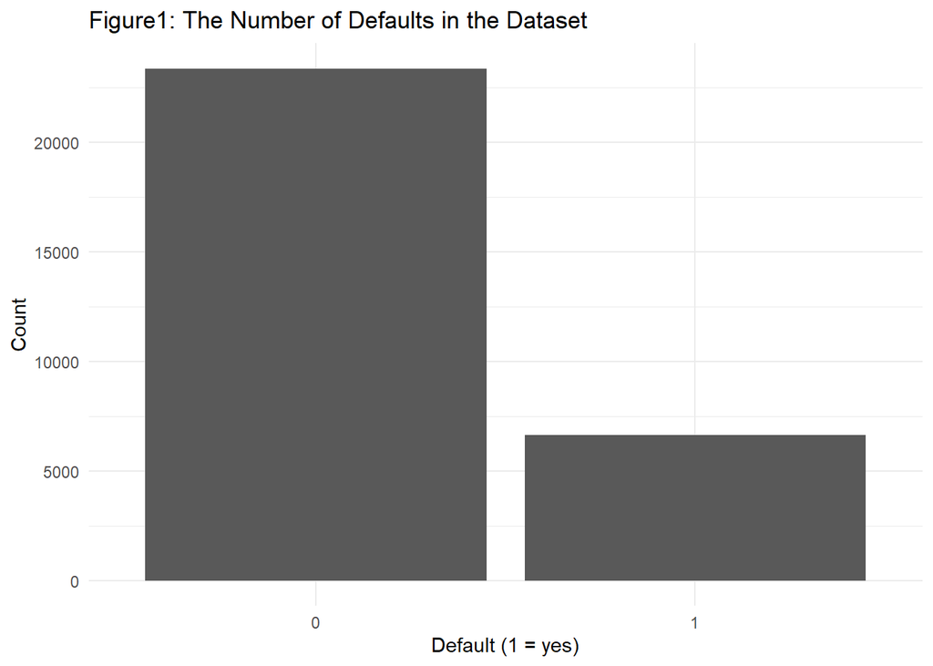

```r
creditDf %>%
  ggplot(aes(x = default.payment.next.month)) +
  geom_bar() +
  ylab('Count') +
  xlab('Default (1 = yes)') +
  ggtitle('Figure1: The Number of Defaults in the Dataset') +
  theme_minimal()
```

Now, we examine the relationship between demographic variables and defaulting.

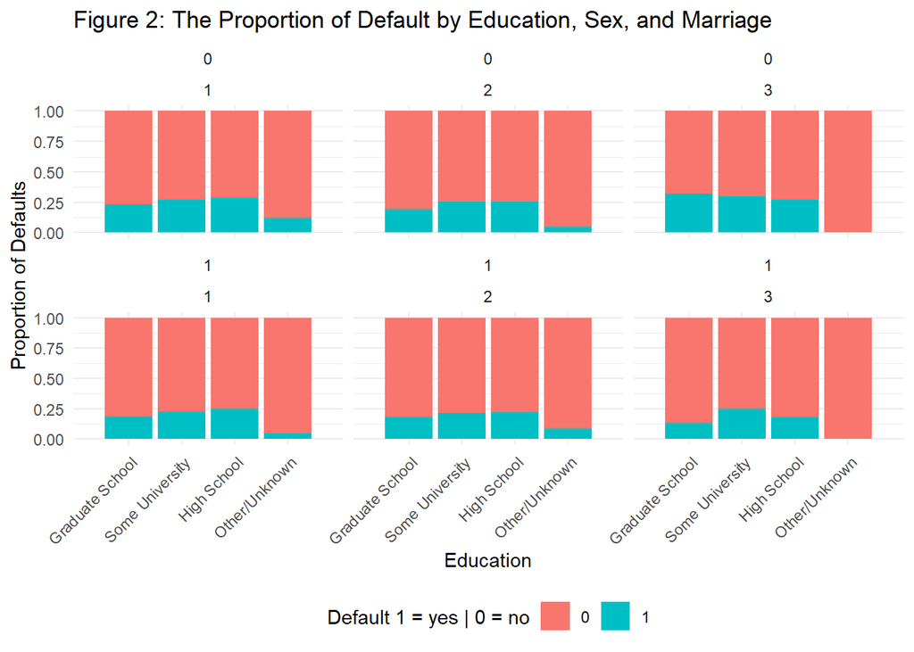

```r
# 1 = Female, 0 = Male
sex.label <- c('Female', 'Male')
names(sex.label) <- c('1', '0')
# 1 = Married, 2 = Single, 3 = Other
marriage.label <- c('Married', 'Single', 'Other')
names(marriage.label) <- c('1', '2', '3')

creditDf %>%
  group_by(sex, marriage, education, default.payment.next.month) %>%
  tally() %>%
  mutate(
    proportion = n/sum(n)
  )  %>%
  ggplot(aes(x = education, y = proportion, fill = default.payment.next.month)) +
  geom_col() +
  facet_wrap(~sex + marriage,
             #labeller(sex = sex.label,
              #        marriage = marriage.label)
             ) +
  xlab('Education') +
  ylab('Proportion of Defaults') +
  labs(fill = 'Default 1 = yes | 0 = no') +
  ggtitle('Figure 2: The Proportion of Default by Education, Sex, and Marriage') +
  theme_minimal() +
  theme(
    legend.position = 'bottom',
    axis.text.x = element_text(angle = 45, hjust = 1)
  ) +
  scale_x_discrete(labels  = c('1' = 'Graduate School', '2' = 'Some University', '3' = 'High School', '4' = 'Other/Unknown'),
                   limits = seq(1, 4)
                   )
```

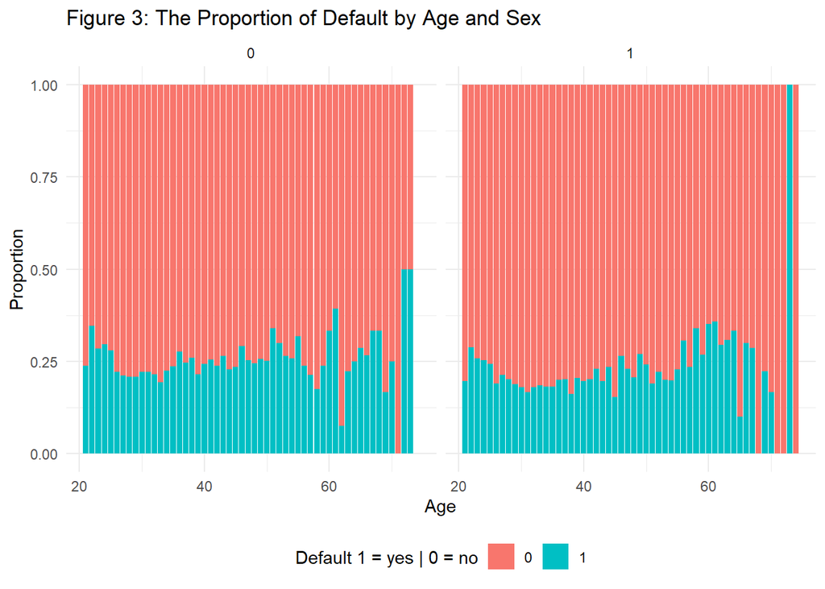

```r
creditDf %>%
  filter(age < 75) %>%
  group_by(age, sex, default.payment.next.month) %>%
  tally() %>%
  mutate(
    proportion = n/sum(n)
  ) %>%
  ggplot(aes(x = age, y = proportion, fill = default.payment.next.month)) +
  geom_col() +
  facet_wrap(~ sex#,
             #labeller(sex = sex.label)
             ) +
  xlab('Age') +
  ylab('Proportion') +
  ggtitle('Figure 3: The Proportion of Default by Age and Sex') +
  labs(fill = 'Default 1 = yes | 0 = no') +
  theme_minimal() +
  theme(
    legend.position = 'bottom'
  )
```

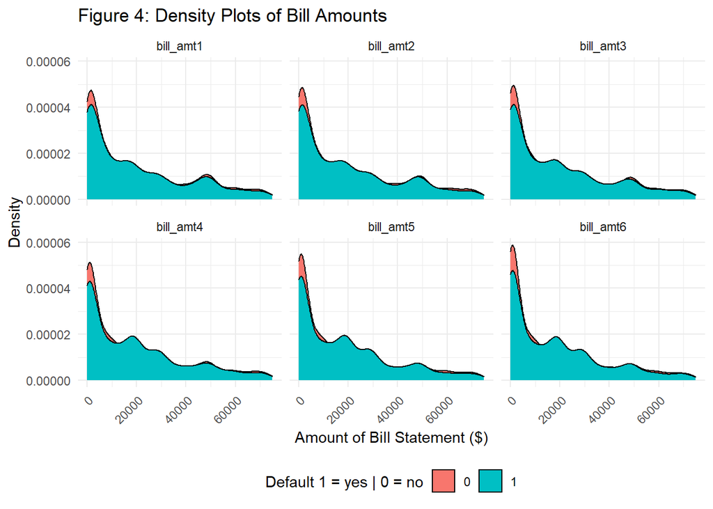

```r
creditDf %>%
  select( bill_amt6, bill_amt5, bill_amt4, bill_amt3, bill_amt2, bill_amt1, default.payment.next.month) %>%
  gather(-default.payment.next.month, key = 'iv', value = 'value') %>%
  ggplot(aes(x = value,  fill = default.payment.next.month)) +
  geom_density() +
  facet_wrap(~iv) +
  xlim(0, 75000) +
  ylab('Density') +
  xlab('Amount of Bill Statement ($)') +
  ggtitle('Figure 4: Density Plots of Bill Amounts') +
  labs(fill = 'Default 1 = yes | 0 = no') +
  theme_minimal() +
  theme(
    legend.position = 'bottom',
    axis.text.x = element_text(angle = 45, hjust = 1)
  )
```

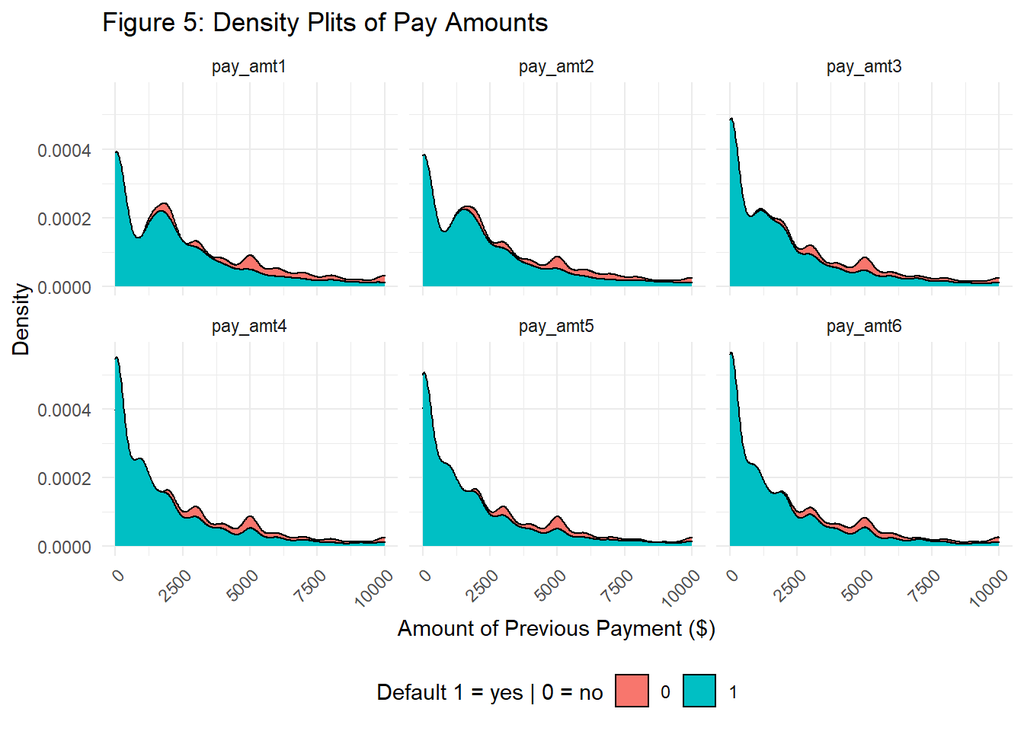

```r
creditDf %>%
  select( pay_amt6, pay_amt5, pay_amt4, pay_amt3, pay_amt2, pay_amt1, default.payment.next.month) %>%
  gather(-default.payment.next.month, key = 'iv', value = 'value') %>%
  ggplot(aes(x = value,  fill = default.payment.next.month)) +
  geom_density() +
  facet_wrap(~iv) +
  xlim(0, 10000) +
  ylab('Density') +
  xlab('Amount of Previous Payment ($)') +
  labs(fill = 'Default 1 = yes | 0 = no') +
  ggtitle('Figure 5: Density Plits of Pay Amounts') +
  theme_minimal() +
  theme(
    legend.position = 'bottom',
    axis.text.x = element_text(angle = 45, hjust = 1)
  )
```

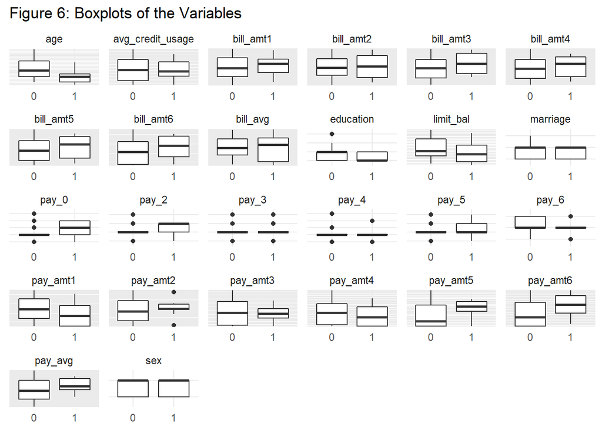

```r
creditDf %>%
  sample_n(50) %>% #samples from the data set to improve speed
  gather(-default.payment.next.month, key = 'iv', value = 'value') %>%
  ggplot(aes(y = value,  group = default.payment.next.month, x = default.payment.next.month)) +
  geom_boxplot() +
  facet_wrap(~iv, scales = 'free') +
  ggtitle('Figure 6: Boxplots of the Variables') +
  theme_minimal() +
  theme(
    axis.text.y = element_blank(),
    axis.title.x = element_blank(),
    axis.title.y = element_blank()
  )
```

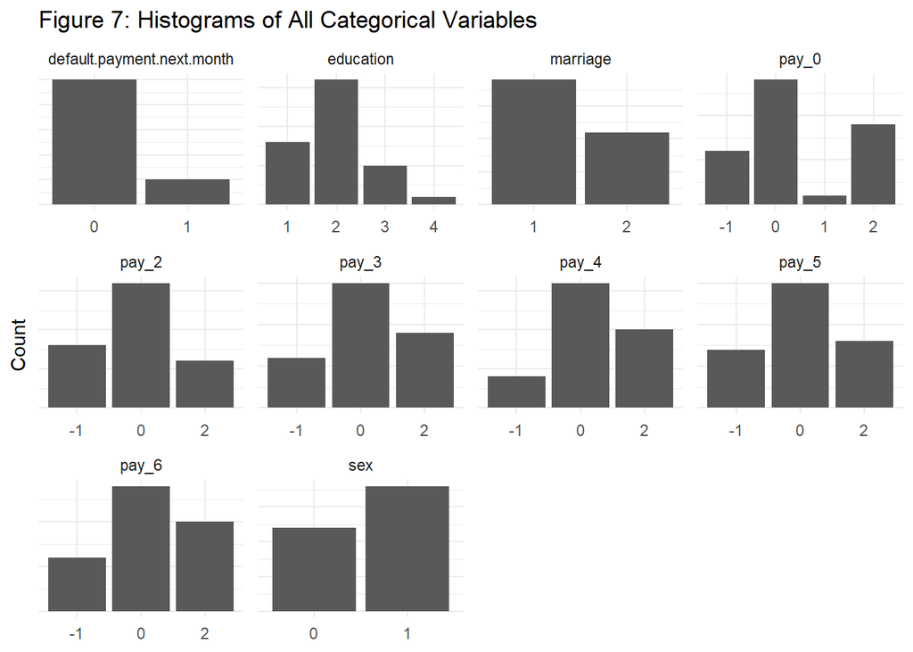

```r
#histograms of categorical data
categorical %>%
  sample_n(30) %>%
  gather(key = 'var', value = 'value') %>%
  ggplot(aes(x = value)) +
  geom_histogram(stat = 'count') +
  facet_wrap(~var, scales = 'free') +
  xlab('Variable') +
  ylab('Count') +
  ggtitle('Figure 7: Histograms of All Categorical Variables') +
  theme_minimal() +
  theme(
    #axis.text.x = element_text(angle = 45, hjust = 1),
    axis.text.y = element_blank(),
    axis.title.x = element_blank()
  )
```